# Lab No.0 - DESCRIPTIVO

Ricardo Alvarado B.

10 de agosto de 2017

# Descripción

Se realizó un estudio para analizar la velocidad de nado de las personas mayores de 18 años que son miembros regulares de un equipo de natación, y se tomaron en cuenta algunas variables que pueden estar relacionadas con esta velocidad. Se hizo una prueba a los participantes y se tomó el tiempo que duraban en nadar 50m. Entonces como medida de la velocidad de nado se tiene el tiempo (en segundos) el cual se puede transformar a la velocidad dividiendo la distancia entre el tiempo. Esta variable se llama **veloc**. Como variables predictoras se tienen las siguientes:

1. **edad**: la edad en años cumplidos.
2. **sexo**: el sexo codificado como 0 (mujeres) y 1 (hombres).
3. **imc**: el índice de masa corporal se calcula dividiendo el peso en kilogramos entre la altura al cuadrado (en metros), lo cual da una medida en kg/m<sup>2</sup>.
4. **pierna**: la longitud promedio de ambas piernas (en centímetros).
5. **brazo**: la longitud promedio de ambos brazos (en centímetros).

# Ejercicios

1. Lea el archivo de datos con **load(“velo.Rdata”)**. Observe que adentro del archivo que ha leído se encuentra un objeto llamado **base**. Llame ese objeto y observe su contenido.

setwd(“~/Dropbox/escuela de estadística/Codigo Cursos/laboratorios_1/Lab. No.0 - DESCRIPTIVO”)

```r
load("velo.Rdata")
base
```

```
##        veloc edad sexo      imc pierna brazo
## 1  1.4128285   22    0 21.14769 100.50 72.00
## 2  1.3071895   20    0 21.95529 100.00 70.00
## 3  1.2903226   18    0 23.62755  96.00 68.50
## 4  1.2251899   20    0 19.72104 102.00 70.50
## 5  1.3698630   22    0 25.19531  97.50 68.00
## 6  1.4988010   21    1 21.29529 103.50 74.75
## 7  1.4168320   23    1 24.48565 115.00 80.00
## 8  1.5342129   23    1 22.64738  98.50 73.00
## 9  1.7277125   22    1 19.20415 104.50 74.00
## 10 1.5192950   24    0 23.43374  99.00 72.00
## 11 1.7605634   20    1 22.88750  99.50 73.50
## 12 1.2106538   38    1 24.02128 114.50 79.75
## 13 1.5948963   33    1 22.77614 116.00 87.00
## 14 0.9100837   39    1 25.52055 100.00 75.50
```

[output cut: 16 more lines]

2. Una forma elegante de observar lo que contiene un archivo de datos es mediante la función “str”, en tal caso escriba **str(base)** y observe el tipo de datos que contiene.

```r
str(base)
```

```
## 'data.frame':    30 obs. of  6 variables:
##  $ veloc : num  1.41 1.31 1.29 1.23 1.37 ...
##  $ edad  : num  22 20 18 20 22 21 23 23 22 24 ...
##  $ sexo  : num  0 0 0 0 0 1 1 1 1 0 ...
##  $ imc   : num  21.1 22 23.6 19.7 25.2 ...
##  $ pierna: num  100.5 100 96 102 97.5 ...
##  $ brazo : num  72 70 68.5 70.5 68 ...
```

- En particular vea que **sexo** es numérica y no se sabe a qué corresponde cada código. Debido a su naturaleza de variable categórica debería de convertirse a factor y asignar nombres a los niveles para que éstos puedan ser claramente identificados. Para convertir **sexo** en factor use **base$sexo=factor(base$sexo)**. Observe los niveles de sexo con **levels(base$sexo)** y vea que está primero el **0** y luego el **1**, entonces para asignar los códigos debe hacerlo en ese orden, es decir, primero **“mujer”** que corresponde al **0** y luego **“hombre”** que corresponde al **1**. En este caso escriba **levels(base$sexo)=c(“mujer”,“hombre”)**. Observe ahora la variable **sexo**.

```r
base$sexo=factor(base$sexo)
levels(base$sexo)
```

```
## [1] "0" "1"
```

```r
levels(base$sexo)=c("mujer","hombre")
base$sexo
```

```
##  [1] mujer  mujer  mujer  mujer  mujer  hombre hombre hombre hombre mujer
## [11] hombre hombre hombre hombre hombre hombre mujer  hombre mujer  hombre
## [21] hombre hombre hombre mujer  mujer  hombre hombre hombre hombre hombre
## Levels: mujer hombre
```

3. Haga un gráfico donde se muestre la relación entre la edad y la velocidad. En este caso la velociad funciona como **variable respuesta** porlo que debe colocarse en el **eje Y**, mientras que la edad funciona como **variable explicativa** por lo que debe colocarse en el **eje X**. Para hacer este gráfico use la función **plot**. Recuerde que puede cambiar los símbolos de graficación con el parámetro **pch** y poner color con el parámetro **col**. Además de poner nombres adecuados en los ejes, como por ejemplo poner **velocidad** en el **eje Y** en lugar de **veloc**, para esto puede agregar dentro de la función lo siguiente: **ylab=“velocidad”**.

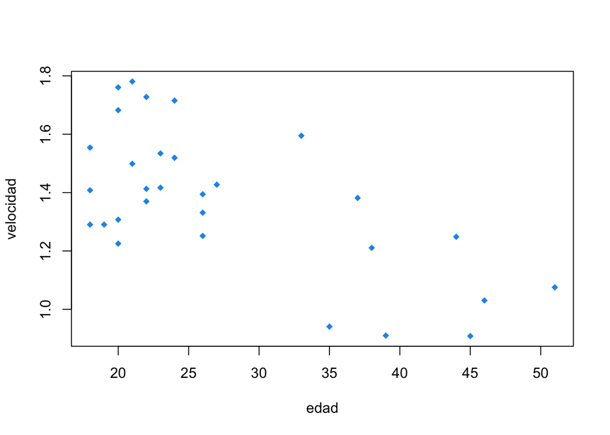

```r
plot(veloc~edad,pch=18,col=4,ylab="velocidad",data=base)
```

- ¿Se puede decir que al aumentar la edad disminuye la velocidad de nado?
4. Este gráfico se puede hacer de forma más elegante con la biblioteca **lattice**. Puede usar el comando **xyplot** y agregar una línea de tendencia con el parámetro **type=c(“p”,“r”)**, donde la **p** indica que ponga puntos y **r** indica que agregue una línea de regresión. Quedaría de la siguiente forma: **xyplot(veloc~edad,type=c(“p”,“r”))**.

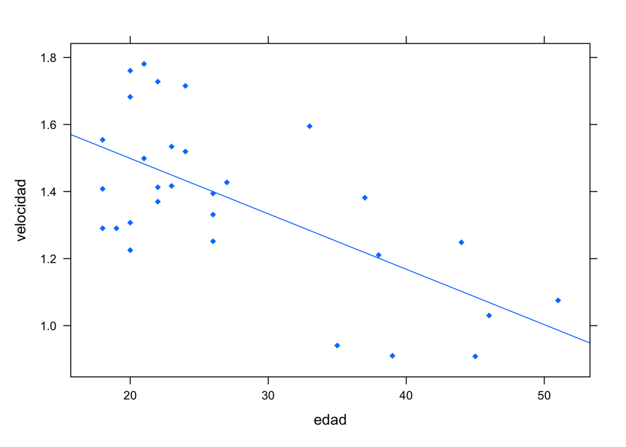

```r
library(lattice)
xyplot(veloc~edad,type=c("p","r"),pch=18,ylab="velocidad",data=base)
```

- ¿Qué se puede decir al ver esta línea de tendencia?
5. Interesa analizar la velocidad promedio de este grupo de personas.
- Primero obtenga el promedio de velocidad de todo el grupo simplemente usando la función **mean**.
- Cree ahora una nueva variable categórica basada en la variable **edad** la cual es originalmente numérica. Primero obtenga un summary da la variable **edad** y vea el mínimo y el máximo. También puede hacer un histograma de esa variable usando la función **hist**. De esta forma se decide que partiendo la edad los siguientes puntos de corte se tendría suficientes datos en cada categoría. Los puntos pueden ser: 10, 20, 30, 40, 50 y 60. Para convertir una variable numérica en categórica se usa la función **cut** y se indican los puntos de corte con el argumento **breaks**, de la siguiente forma: **cut(base$edad,breaks=c(10,20,30,40,50,60))**.
- Obtenga la media de velocidad de cada categoría de edad en la variable creada anteriormente (**edadcat**), para esto puede usar la función **tapply** indicando primero la variable que se va a promediar, seguida por la variable categórica y finalmente la función que se aplica. En general sería de la siguiente forma: **tapply(y,factor,funcion)**.
- Represente gráficamente la relación que hay entre el punto de medio de cada intervalo de edad y la velocidad promedio.
- Repita los pasos anteriores pero con puntos de corte cada 5 años en lugar de hacerlo cada 10 años.

```r
mean(base$veloc)
```

```
## [1] 1.373278
```

```r
summary(base$edad)
```

```
##    Min. 1st Qu.  Median    Mean 3rd Qu.    Max.
##   18.00   20.25   23.50   27.60   34.50   51.00
```

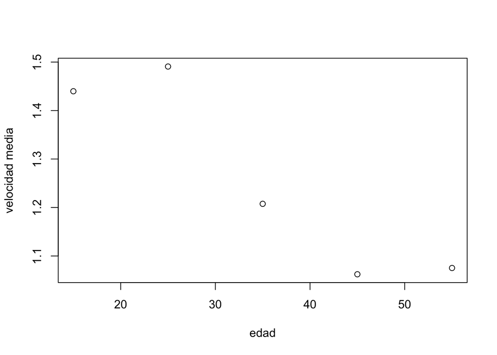

```r
basecat=cut(base$edad,breaks=seq(10,60,10))
med=tapply(base$veloc,basecat,mean)
plot(seq(15,55,10),med,xlab="edad",ylab="velocidad media")
```

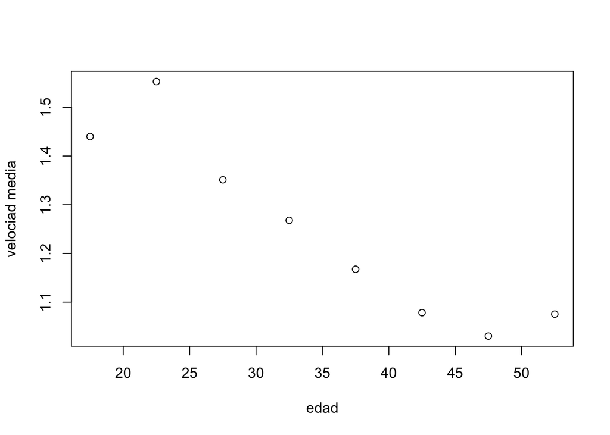

```r
basecat=cut(base$edad,breaks=seq(15,55,5))
med=tapply(base$veloc,basecat,mean)
plot(seq(17.5,52.5,5),med,xlab="edad",ylab="velociad media")
```

```r
library(car)
```

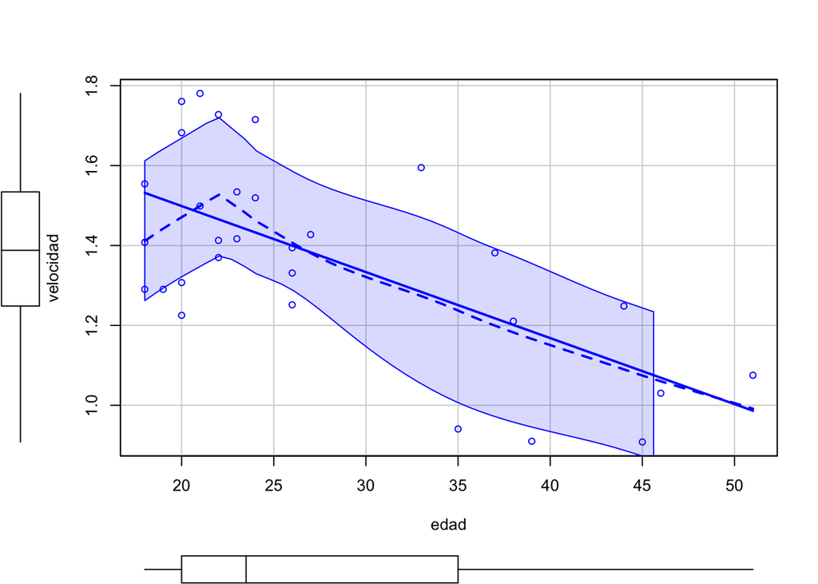

```r
with(base,scatterplot(edad,veloc,ylab="velocidad"))
```

- Escriba con sus palabras qué representa cada punto de la línea de regresión paramétrica y no paramétrica.
6. Ahora interesa hacer un gráfico similar al anterior pero donde se reconozcan los hombres y las mujeres. Se podrían hacer dos gráficos por separado, o uno solo con dos líneas. Para hacer los gráficos por separado se agrega en la función **xyplot** una la indicación **|sexo** después de la variable que aparece en el **eje X**, es decir inmediatamente después de **edad**. Para hacer un solo gráfico con dos líneas se agrega un nuevo parámetro **groups=sexo**. En este caso se agrega el parámetro **auto.key=T** para que queden etiquetados los puntos según su sexo.

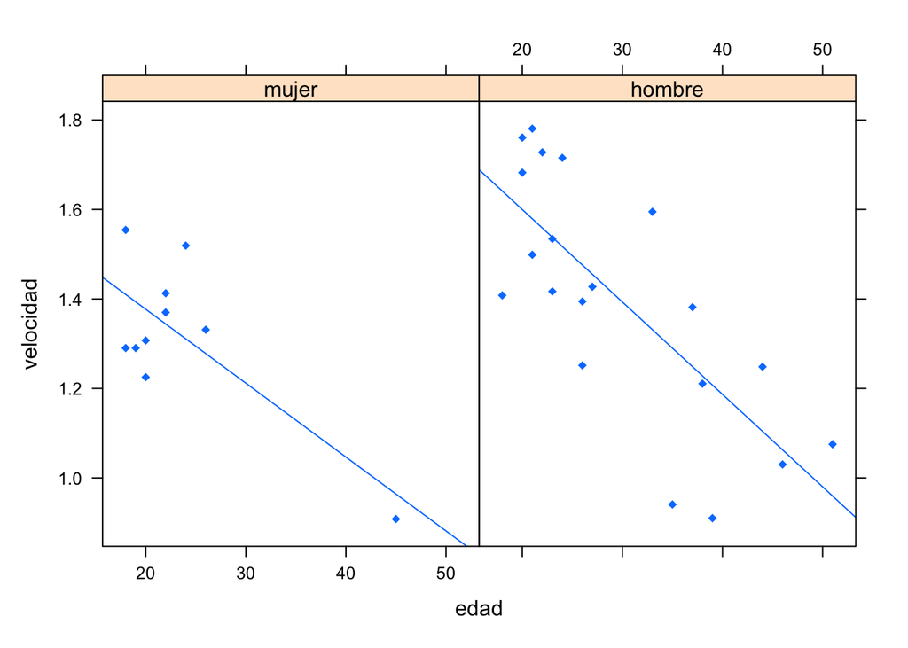

```r
xyplot(veloc~edad|sexo,type=c("p","r"),pch=18,ylab="velocidad",data=base)
```

- ¿Se observa alguna tendencia diferente en hombres y mujeres?

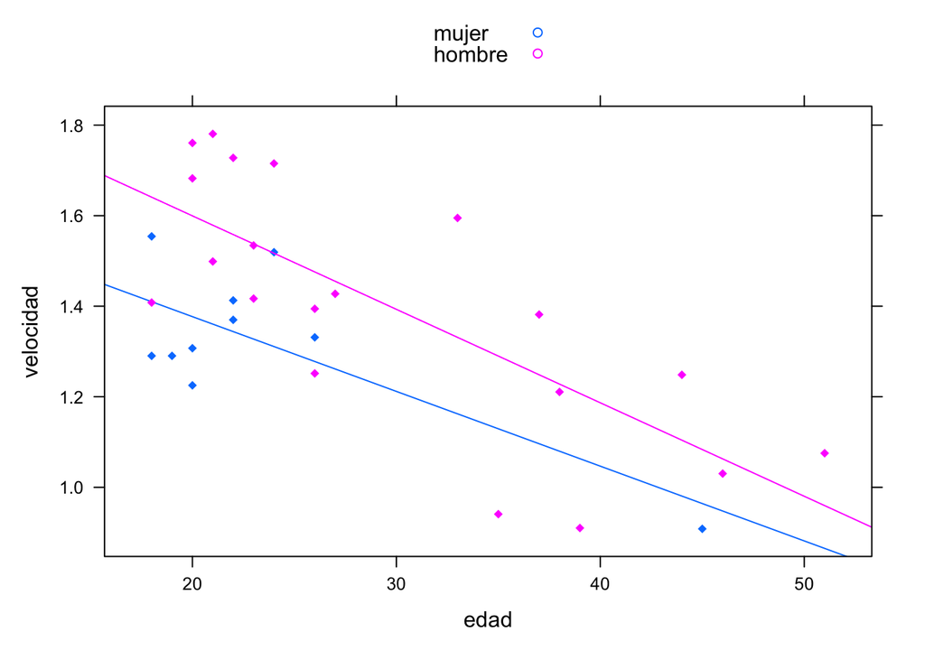

```r
xyplot(veloc~edad,groups=sexo,type=c("p","r"),pch=18,ylab="velocidad",
auto.key=T,data=base)
```

+Para dos personas con 20 años no necesariamente el hombre va a tener siempre una velociad mayor que la mujer, pero es más probable. En cambio a nivel de promedio sí esperaría que los hombres de 20 años tengan una velocidad mayor en promedio que las mujeres de 20 años

# Recapitulación

- ¿Cuales librerías utilizó en este laboratorio?
- ¿Cuáles funciones utilizó en este laboratorio?
- ¿Cómo se convierte una variable numérica en factor? ¿Cómo se asignan los niveles a un factor?
- ¿Cómo se categoriza una variable numérica en intervalos?
- ¿Cómo se representa la relación entre dos variables numéricas donde una de ellas actúa como respuesta y la otra como variable explicativa?
- ¿Cómo se obtiene la media de una variable para diferentes niveles de una variable categórica?
- ¿Cómo se obtiene e interpreta una línea de tendencia según el modelo de regresión lineal?
- ¿Cómo se obtiene e interpreta una línea suavizada de regresión no paramétrica?
- ¿Cómo se representa la relación entre dos variables numéricas diferenciando esta relación según los niveles de otra variable categórica?